# hw4

```r
library(sparklyr)
library(ggplot2)
library(dplyr)
library(mapdata)
library(ggrepel)
```

```r
Sys.setenv(SPARK_HOME="/usr/lib/spark")
config <- spark_config()
sc <- spark_connect(master = "yarn-client", config = config)
sc
```

[output not shown]

```r
flights_tbl <- tbl(sc, 'flights')
airlines_tbl <- tbl(sc, 'airlines')
airports_tbl <- tbl(sc, 'airports')
```

## 1. Map the top 10 busiest airports. Size of dots should reflect the number of flights through that destination.

```r
usa <- map_data('usa')
```

The datasets I will mostly be working with throughout the rest of this exploratory analysis:

```r
airports <- airports_tbl %>%
  select(faa, lat, lon) %>%
  collect()
```

```r
flight_data <- flights_tbl %>%
  select(year, month, dayofmonth,
         origin, dest) %>%
  filter(year == 1987) %>%
  collect()
```

```r
all <- flights_tbl %>%
  select(year, month, dayofmonth,
         origin, dest) %>%
  filter(year >= 1998) %>%
  filter(origin == 'LAX'|dest == 'LAX') %>%
  collect()
```

Let’s continue with code:

```r
busiest10 <- all %>% select(origin, dest) %>%
  group_by(origin) %>% summarize(cnt = n()) %>%
  arrange(desc(cnt)) %>%
  collect()
```

```r
busiest10_dest <- all %>% select(origin, dest) %>%
  group_by(dest) %>% summarize(cnt2 = n()) %>%
  arrange(desc(cnt2)) %>%
  collect()
```

```r
busiest10 <- busiest10 %>% head(10) %>%
  rename(airport = origin)

busiest10_dest <- busiest10_dest %>% head(10) %>%
  rename(airport = dest)

busiest10 <- busiest10 %>%
  inner_join(busiest10,
             busiest10_dest, by = 'airport') %>%
  mutate(sum = rowSums(.[2:3])) %>%
  arrange(desc(sum))

busiest10$rank <- seq(1:10)
```

```r
busiest_coord <- airports %>%
  select(faa, lat, lon) %>%
  filter(faa %in% busiest10$airport) %>%
  mutate(lat = as.numeric(as.character(lat)),
         lon = as.numeric(as.character(lon))) %>%
  rename(airport = faa) %>%
  inner_join(busiest10[,c('airport','rank')], by = 'airport')
```

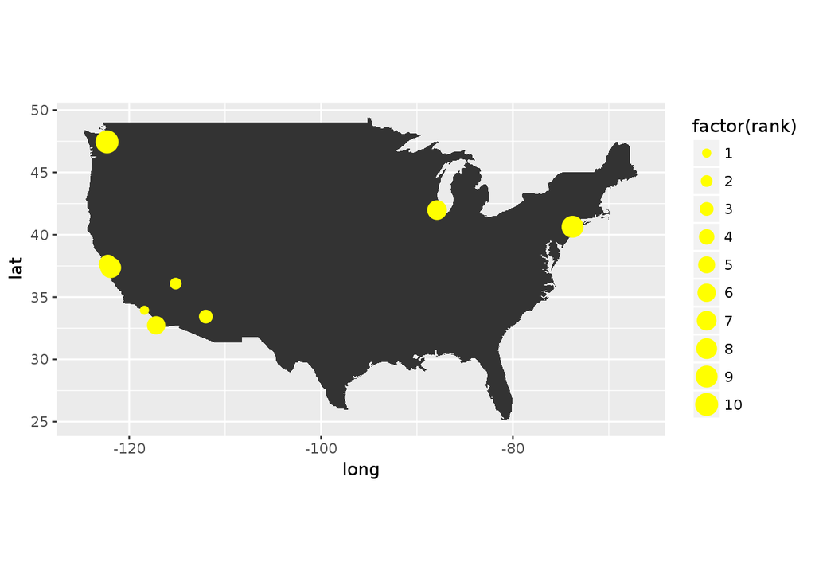

```r
usa <- map_data("usa")
base_map <- ggplot() + geom_polygon(data = usa,
                                      aes(x = long, y = lat, group = group)) +
                      coord_fixed(1.3)
base_map + geom_point (data = busiest_coord,
                       aes(x = lon, y = lat, size = factor(rank)),
                       color = 'yellow')
```

Here my bubbles are a bit counter intuitivitie. The smallest dot represents the busiest airport (LAX in Los Angeles), while the largest dot represents the least busy airport (SEA in Seattle). These can be seen above.

## 2. Map the top 10 busiest direct routes. Size of lines should reflect the number of flights through that route.

```r
busiest_route <- flight_data %>%
  select(year, origin, dest) %>%
  group_by(origin, dest) %>%
  summarize(n = n()) %>%
  collect()
```

```r
busiest_route <- busiest_route %>%
  arrange(desc(n)) %>%
  head(10) %>% ungroup() %>%
  mutate(rank = seq(1:10))

origin_coords <- airports %>%
  select(lat, lon, faa) %>%
  filter(faa %in% busiest_route$origin) %>%
  rename(origin = faa) %>%
  collect()

dest_coords <- airports %>%
  select(lat, lon, faa) %>%
  filter(faa %in% busiest_route$dest) %>%
  rename(dest = faa, lat_dest = lat, lon_dest = lon) %>%
  collect()

busiest_route2 <- inner_join(busiest_route, origin_coords, by = 'origin')
busiest_route2 <- inner_join(busiest_route2, dest_coords, by = 'dest')
busiest_route2 <- busiest_route2 %>%
  mutate(lat = as.numeric(lat),
         lon = as.numeric(lon),
         lat_dest = as.numeric(lat_dest),
         lon_dest = as.numeric(lon_dest))
```

```r
airports_n<-sort(unique(c(busiest_route2$origin,
                        busiest_route2$dest)))

lat_lon <- airports %>% select(faa, lat, lon) %>%
  filter(faa %in% airports_n) %>%
  collect() %>% arrange(faa)

airports_1 <- data.frame(airport = airports_n, lat_lon[,2:3])
airports_1 <- airports_1 %>% mutate(lat = as.numeric(lat),
                                lon = as.numeric(lon))
```

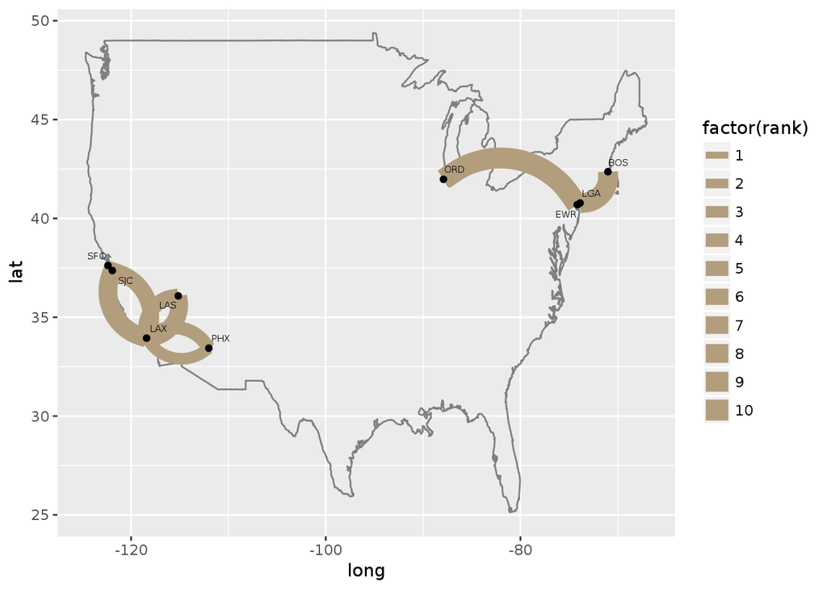

```r
usamap <- borders("usa")

ggplot() + usamap + geom_curve(data = busiest_route2,
             aes(x = lon, y = lat,
                 xend = lon_dest, yend = lat_dest, size = factor(rank)),
             col = "#b29e7d") +
          geom_point(data = airports_1,
                     aes(x = lon, y = lat)) +
          geom_text_repel(data=airports_1,
                  aes(x = lon, y = lat, label = airport),
                  col = "black", size = 2,
                  segment.color = NA)
```

The 10 most common routes are plotted above. It should be noted that the line is counterintuitive as well. A thicker line represents a less common flight while a thinner line represents a more common flight.

## 3.

```r
air_traf <- all %>%
  select(year, month, dayofmonth, origin, dest) %>%
  filter(year >= 1998) %>%
  filter(origin == 'LAX'|dest == 'LAX') %>%
  group_by(year, month, dayofmonth) %>%
  summarize(cnt= n()) %>%
  collect()

air_traf
```

```
## # A tibble: 4,018 x 4
## # Groups:   year, month [?]
##     year month dayofmonth   cnt
##    <int> <int>      <int> <int>
##  1  1998     1          1   926
##  2  1998     1          2   993
##  3  1998     1          3   950
##  4  1998     1          4  1011
##  5  1998     1          5  1051
##  6  1998     1          6  1031
##  7  1998     1          7  1020
##  8  1998     1          8  1020
##  9  1998     1          9  1021
## 10  1998     1         10   902
## # ... with 4,008 more rows
```

```r
air_traf <- air_traf %>%
  ungroup() %>%
  mutate(fin_date = as.Date(with(air_traf, paste(year, month,
                                         dayofmonth,
                                         sep = '-')),
         '%Y-%m-%d'))

important <- data.frame(
  events <- c("2001-09-11", "2004-11-24", "2004-07-04",
              "2008-01-01", "2001-01-01"),
  n <- c(1100, 1000, 1050, 1200, 1200),
  num <- c(1, 2, 3, 4, 5),
  stringAsFactors <- FALSE)
```

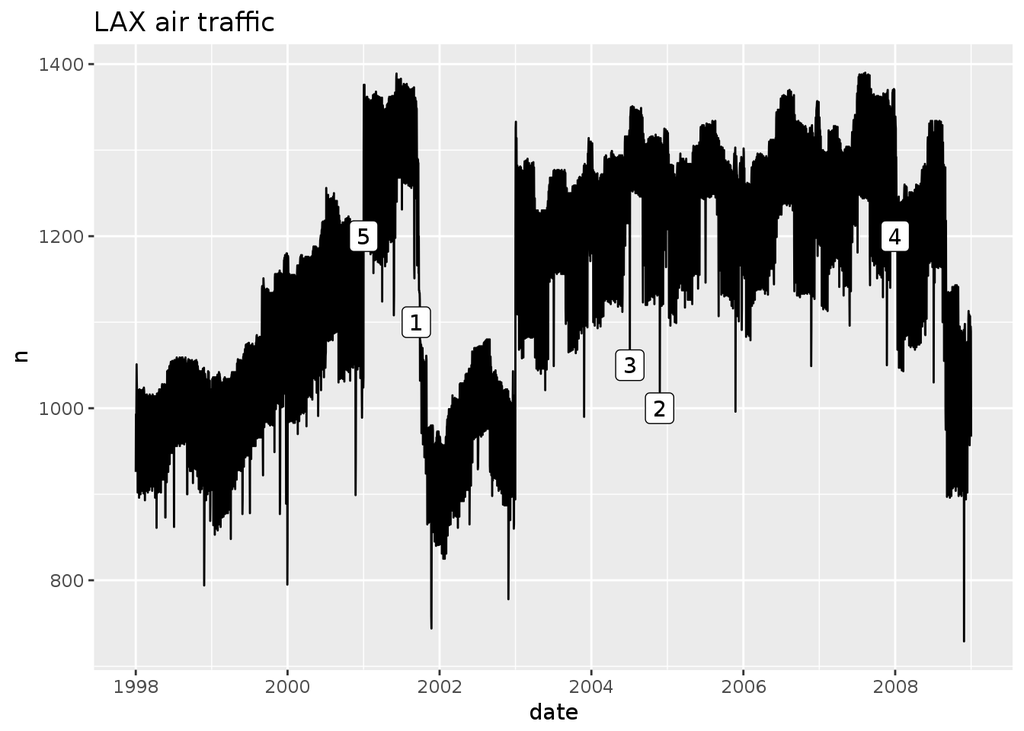

```r
ggplot(data = air_traf) +
  geom_line(mapping = aes(x = fin_date, y = cnt)) +
  geom_label(data = important, aes(x = as.Date(events,
                                                 "%Y-%m-%d"), y = n,
                                     label = num)) +
  labs(x = 'date',
      y = 'n',
      title = 'LAX air traffic')
```

### b. Visualize and explain seasonal effects.

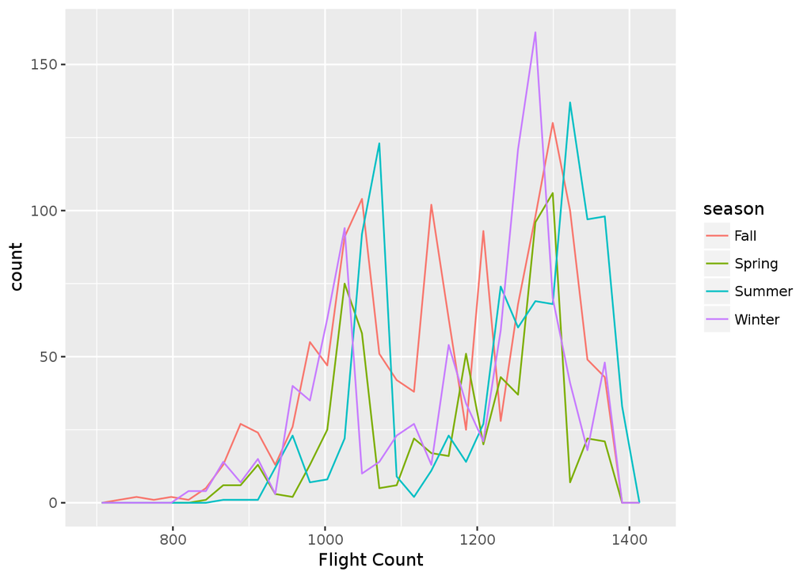

```r
air_traf <- air_traf %>% ungroup() %>%
  mutate(season = ifelse(month >= 1 & month <=3, 'Winter',
                        ifelse(month >= 4 & month <6, 'Spring',
                          ifelse(month >= 6 & month <= 8, 'Summer',
                                ifelse(month >= 9 & month <=12, 'Fall',
                                'F')))))

ggplot(data = air_traf) +
  geom_freqpoly(mapping = aes(x = cnt, color = season)) +
  labs(x = 'Flight Count')
```

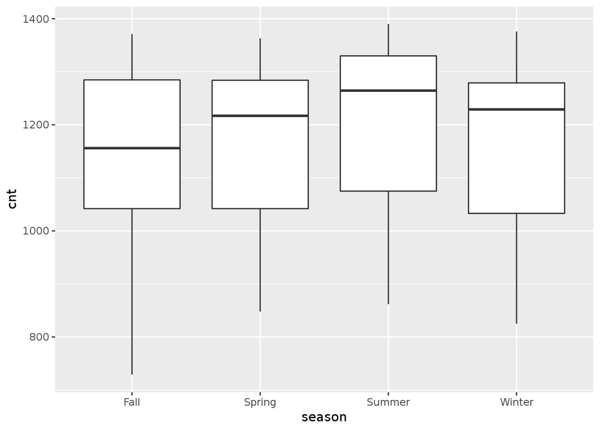

```r
ggplot(data = air_traf) +
  geom_boxplot(mapping = aes(x = season, y = cnt))
```

I added a ‘season’ variable that was broken up into Fall, Spring, Summer, and Winter. Seasonal effects are more efficiently understood by the repeated boxplot graphs pictured above. We see that the median number of flights coming in and out of LA is the smallest in the fall. The fall also has the most variability. Summer has the highest median number of flights coming in and out of LA which would make sense since adolescents and college students are off for the entire summer making it a good time to travel; many people are off work as well. Winter and spring have the lower median number of flights. The amount of variability in the number of flights is similar between spring, winter, and summer. The frequency polygons demonstrate similar effects.

### c. Visualize and explain weekly effects.

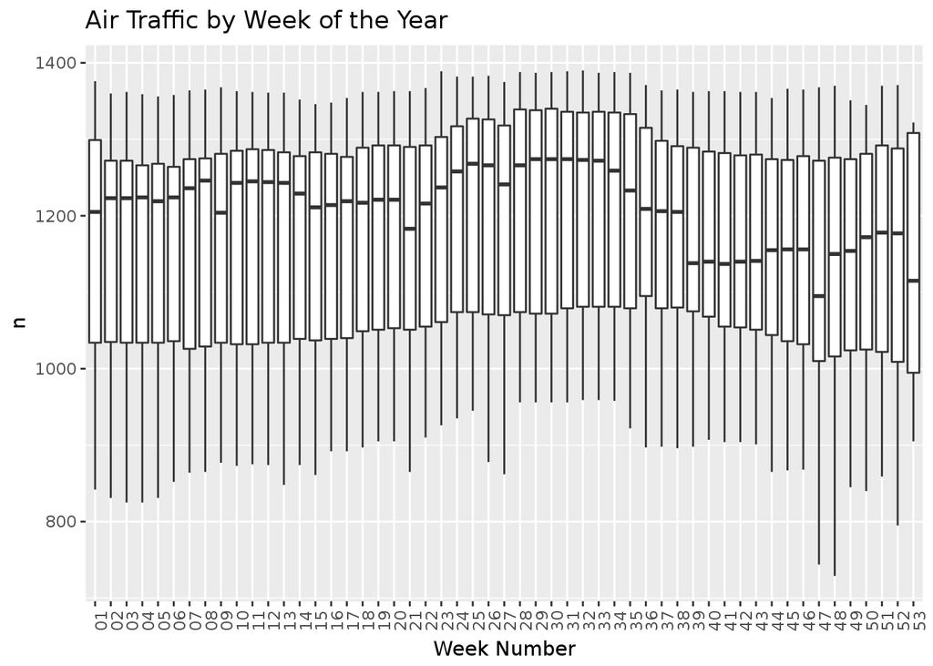

```r
air_traf <- air_traf %>%
  mutate(wknum = strftime(fin_date, format = '%V'))

ggplot(data = air_traf) +
  geom_boxplot(mapping=aes(x = wknum, y = cnt)) +
  labs(x = 'Week Number',
       y = 'n',
       title = 'Air Traffic by Week of the Year') +
  theme(axis.text.x = element_text(angle = 90, hjust = 1))
```

I also did repeated boxplots for this graph as well. We see that the median number of flights coming in and out of LAX is lower at the end of the year from weeks 39 to 53. In particular, we see a sudden dip during Week 47– Thanksgiving Week. This might explain the large variability in Week 47 as well because a lot of people are flying out during the first half of the week but very people are flying out during the actual Thanksgiving weekend. We also see peaks during the summer particularly start from Week 29 (approximately end July) to Week 33 (mid August).

### d. Map top 10 destinations from LAX. Size of dots should reflect the number of flights from LAX to that destination.

```r
top10_lax <- all %>%
  select(year, month, dayofmonth, origin, dest) %>%
  filter(origin == 'LAX') %>%
  filter(year >= 1998) %>%
  group_by(dest) %>%
  summarize(cnt = n()) %>%
  collect()
```

```r
top10_lax <- top10_lax %>% arrange(desc(cnt))
```

```r
flight_coords <- airports %>%
  select(faa, lat, lon) %>%
  filter(faa %in% top10_lax$dest) %>%
  rename(dest = faa) %>%
  collect()

la_coords <- airports %>%
  select(faa, lat, lon) %>%
  filter(faa == 'LAX') %>%
  rename(origin = faa,
         la_lat = lat,
         la_lon = lon)

top10_lax <- inner_join(top10_lax, flight_coords, by = 'dest')
top10_lax$origin <- rep('LAX', 104)
top10_lax <- inner_join(top10_lax, la_coords, by = 'origin')
```

```r
top10_lax <- top10_lax %>%
  mutate(lat = as.numeric(lat),
         lon = as.numeric(lon),
         la_lat = as.numeric(la_lat),
         la_lon = as.numeric(la_lon))

top10_lax <- top10_lax %>%
  arrange(desc(cnt)) %>%
  head(10) %>% ungroup() %>%
  mutate(rank = seq(1:10))
```

```r
airports_2<-sort(unique(c(top10_lax$origin,
                        top10_lax$dest)))

lat_lon <- airports %>% select(faa, lat, lon) %>%
  filter(faa %in% airports_2) %>%
  collect() %>% arrange(faa)

airports_2 <- data.frame(airport = airports_2, lat_lon[,2:3])
airports_2 <- airports_2 %>% mutate(lat = as.numeric(lat),
                                lon = as.numeric(lon))
```

```r
top10_lax <- top10_lax %>%
  rename(airport = dest) %>%
  arrange(airport)
```

```r
airports_2 <- airports_2 %>% filter(airport != 'LAX') %>%
  arrange(airport) %>%
  mutate(rank = top10_lax$rank)
```

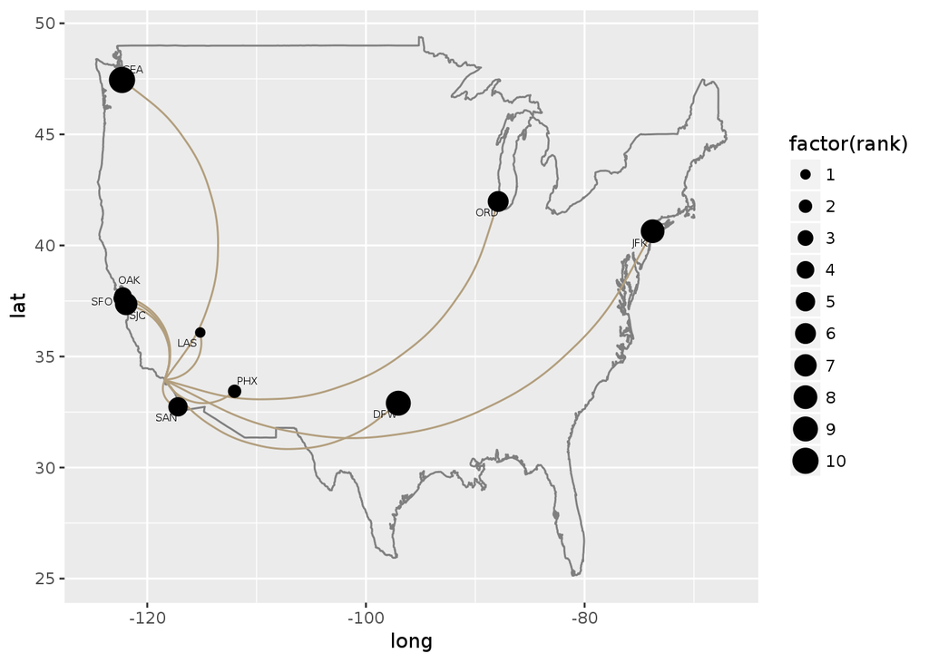

```r
usamap2 <- borders("usa")

ggplot() + usamap2 + geom_curve(data = top10_lax,
             aes(x = la_lon, y = la_lat,
                 xend = lon, yend = lat),
             col = "#b29e7d") +
          geom_point(data = airports_2,
                     aes(x = lon, y = lat, size = factor(rank))) +
          geom_text_repel(data=airports_2,
                  aes(x = lon, y = lat, label = airport),
                  col = "black", size = 2,
                  segment.color = NA)
```

## 4. Build a predictive model for the arrival delay (arrdelay) of flights flying from LAX. Use the same filtering criteria as in the lecture notes to construct training and validation sets. You are allowed to use a maximum of 5 predictors. The prediction performance of your model on the validation data set will be an important factor for grading this question.

```r
 model_data <- flights_tbl %>%
    filter(!is.na(arrdelay) & !is.na(depdelay) & !is.na(distance)) %>%
    filter(depdelay > 15 & depdelay < 240) %>%
    filter(arrdelay > -60 & arrdelay < 360) %>%
    filter(year >= 2005 & year <= 2007) %>%
    left_join(airlines_tbl, by = c("uniquecarrier" = "code")) %>%
    select(year, month, arrdelay, depdelay, distance, uniquecarrier,
           description, diverted)
```

```r
model_partition <- model_data %>%
  sdf_partition(train = 0.8, valid = 0.2, seed = 5555)
```

```r
ml1 <- model_partition$train %>%
    ml_linear_regression(arrdelay ~ distance + depdelay + uniquecarrier + diverted)
```

```r
summary(ml1)
```

```
## Call: ml_linear_regression.tbl_spark(., arrdelay ~ distance + depdelay + uniquecarrier + diverted)
##
## Deviance Residuals (approximate):
##     Min      1Q  Median      3Q     Max
## -98.377  -9.806  -2.660   5.645 292.103
##
## Coefficients:
##      (Intercept)         distance         depdelay uniquecarrier_WN
##      1.712163884     -0.003131237      1.015188010     -4.710706799
## uniquecarrier_AA uniquecarrier_MQ uniquecarrier_UA uniquecarrier_OO
##      1.594734231      1.120714811     -0.196731015     -0.754046957
## uniquecarrier_US uniquecarrier_DL uniquecarrier_EV uniquecarrier_XE
##     -0.056533151      1.921195050     -2.287768844      1.431288811
## uniquecarrier_NW uniquecarrier_CO uniquecarrier_OH uniquecarrier_FL
##      2.565093995      1.231651994     -0.440456183      0.643697762
## uniquecarrier_YV uniquecarrier_AS uniquecarrier_B6 uniquecarrier_9E
##     -3.670228141     -0.809797812      2.149449645     -0.562507130
## uniquecarrier_F9 uniquecarrier_HP uniquecarrier_DH uniquecarrier_TZ
##      0.284415438     -3.855343346     -0.163139730      6.112023410
## uniquecarrier_AQ         diverted
##     -3.576440916      0.000000000
##
## R-Squared: 0.8495
## Root Mean Squared Error: 17.68
```

```r
data_2008 <- flights_tbl %>%
  filter(!is.na(arrdelay) & !is.na(depdelay) & !is.na(distance)) %>%
  filter(depdelay > 15 & depdelay < 240) %>%
  filter(arrdelay > -60 & arrdelay < 360) %>%
  filter(year == 2008) %>%
  left_join(airlines_tbl, by = c("uniquecarrier" = "code")) %>%
  select(year, month, arrdelay, depdelay, distance, uniquecarrier,
         description, origin, dest, diverted)
```

```r
carrier <- sdf_predict(ml1, data_2008) %>%
  group_by(description) %>%
  summarize(arrdelay = mean(arrdelay),
            prediction = mean(prediction), freq = n()) %>%
  filter(freq > 10000) %>%
  collect()
```

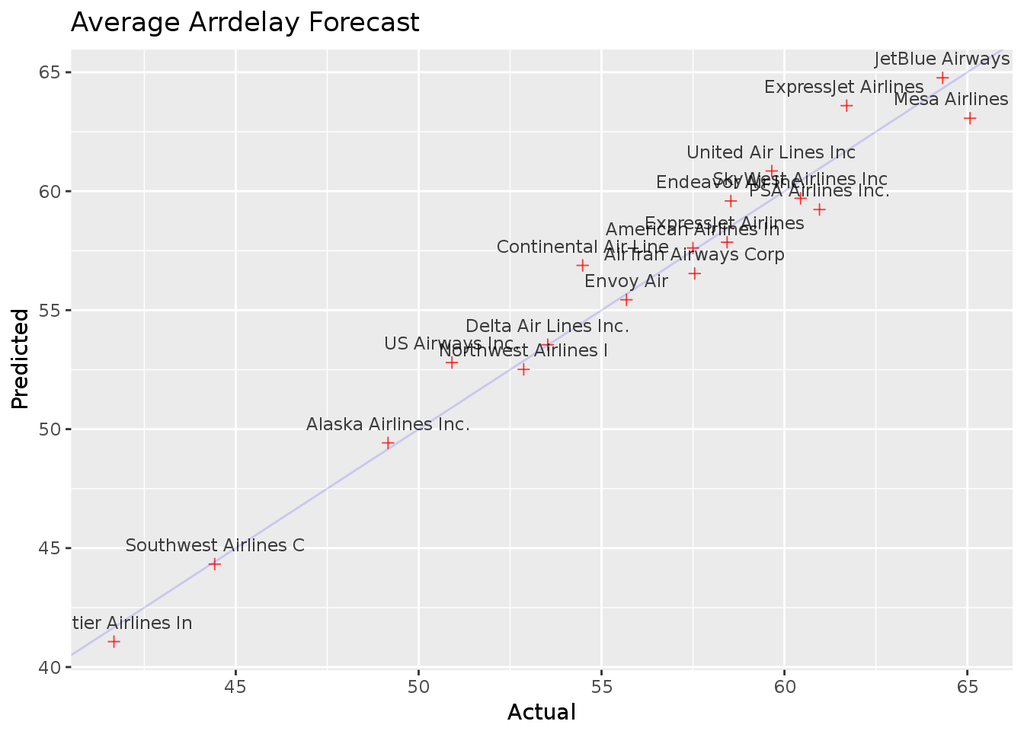

```r
ggplot(carrier, aes(arrdelay, prediction)) +
  geom_point(alpha = 0.75, color = 'red', shape = 3) +
  geom_abline(intercept = 0, slope = 1, alpha = 0.15, color = 'blue') +
  geom_text(aes(label = substr(description, 1, 20)), size = 3, alpha = 0.75, vjust = -1) +
  labs(title='Average Arrdelay Forecast', x = 'Actual', y = 'Predicted')
```

## 5. Visualize and explain any other information you want to explore.

```r
top_dest <- all %>%
  filter(origin == 'LAX') %>%
  select(year, dest) %>%
  group_by(year) %>%
  summarize(number_dests = n())
```

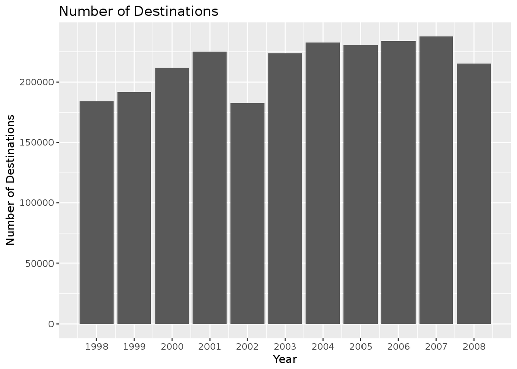

```r
ggplot(data = top_dest) +
  geom_bar(mapping = aes(x = year, y = number_dests), stat = 'identity') +
  labs(x = 'Year', y = 'Number of Destinations',
       title = 'Number of Destinations') +
  scale_x_continuous(breaks = unique(top_dest$year))
```

```r
spark_disconnect_all()
```

```
## [1] 1
```